### A global database for chlorophyll and water chemistry in freshwater lakes

[Alessandro Filazzola](http://www.filazzola.info/), Octavia Mahdiyan, Kevin Blagrave, Carolyn Ewins, Arnab Shuvo, Tanzil Sadid, Luke Moslenko, Mohammad Arshad, [Derek Gray](http://graylaboratory.ca/), [Roberto Quinlan](http://www.yorku.ca/rquinlan/), [Catherine O’Reilly](https://my.ilstu.edu/~cmoreil/index.html) & [Sapna Sharma](https://sharmalab.wordpress.com/)

Part of the York University [Aquatic Research Group](http://www.yorkaquaticresearch.ca/)

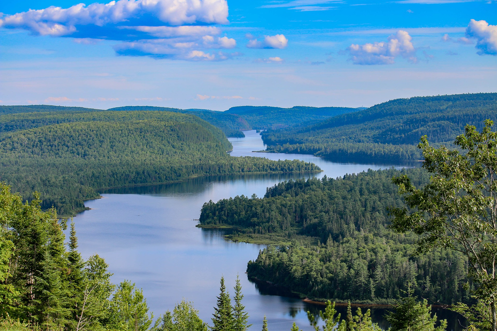

### Abstract

Measures of chlorophyll represent the primary productivity in freshwater lakes that is often used by managers as proxy for water quality. However, the abundance of chlorophyll in lakes is dependent on many interacting factors such as spatial heterogeneity (within and among lakes), climate, and anthropogenic disturbance. Aquatic research examining water chemistry frequently include measures of chlorophyll values and this data is readily available in published manuscripts or online repositories. Thus, there is an opportunity to synthesize a global database on the water chemistry of lakes with focus on chlorophyll. The purpose of this project is to generate a database of freshwater lakes across the globe and through time. We intend to conduct a systematic review examining over 3000 published manuscripts that examined lake chlorophyll and supplement this data with online repositories such as KnB, Dryad, and Pangaea. Using the geospatial coordinates of the lakes we can relate measures of chlorophyll to climate patterns, anthropogenic disturbances, and other changes over time. This database will be used by researchers to improve our understanding of how chlorophyll responds to global change and assist aquatic managers responsible for maintaining water quality in lakes.

### Literature Review

A systematic literature search was conducted using Web of Science for all articles between 2000 and 2018. This time frame was chosen because it captures the majority of the literature that measured chlorophyll values. Papers were excluded that were not primary articles and were not relevant (e.g. virology, sociology, physics, etc)

Data was be extracted from papers or supplemental materials. Authors will be contacted for their available data if not available online. Additional datasets will be obtained used online repostiories (e.g. Dryad, KnB, Github) and more general searches online.

`chlorophyll` **AND** `lake*`

### Load Libraries

```r
#libraries
library(tidyverse)
library(ggmap)
library(dataone)

## get standard error function
se <- function(x) sqrt(var(x)/length(x))

options(scipen=6) ## lower threshold for scientific notation
```

### Download data from KNB

```r
## Select KNB repo for download and database identifiers
cn <- CNode("PROD")
mn <- getMNode(cn, "urn:node:KNB")
id <- "doi:10.5063/F1RV0M1S"
uuid <- "urn:uuid:317170a4-fbe5-4b20-8d32-bdf896b2b75e"


## Get Meta data
library(XML)
metadata <- rawToChar(getObject(mn, id))
doc = xmlRoot(xmlTreeParse(metadata, asText=TRUE, trim = TRUE, ignoreBlanks = TRUE))
tf <- tempfile()
saveXML(doc, tf)
```

```
## [1] "C:\\Users\\alexf\\AppData\\Local\\Temp\\RtmpY9anko\\file15f07aed77c0"
```

```r
file.show(tf)

## Get Raw data
databasePath <- getPackage(mn, id=uuid, dirPath=".", unzip=T)

## List files
list.files(paste0(databasePath,"/data/"))
```

```
## [1] "A_global_database_of_chlorophyll_and_water.xml"
## [2] "ChlaData.csv"
## [3] "doi_10.5063_F1RV0M1S-METADATA.pdf"
## [4] "methodsData.csv"
## [5] "MS_citations.csv"
## [6] "Repo_citations.csv"
## [7] "resourceMap_urn_uuid_317170a4-fbe5-4b20-8d32-bdf896b2b75e.rdf.xml"
```

### Map of studies

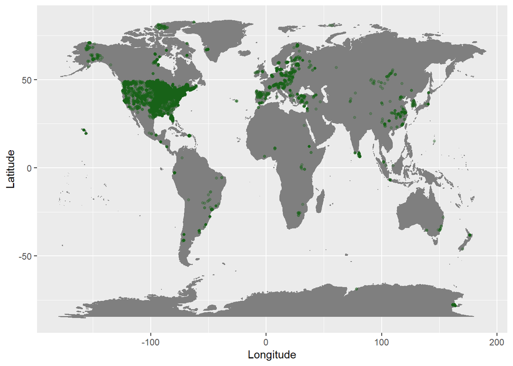

```r
data <- read.csv("data//ChlaData.csv")

## plot out global distribution of lake chl
mp <- NULL
mapWorld <- borders("world", colour="gray50", fill="gray50") # create a layer of borders
mp <- ggplot() +   mapWorld

mp <- mp+ geom_point(data=data , aes(x=Lon, y=Lat), size=1, alpha=0.3, color="#176117") + xlab("Longitude") + ylab("Latitude")
mp
```

### Patterns in chlorophyll distribution

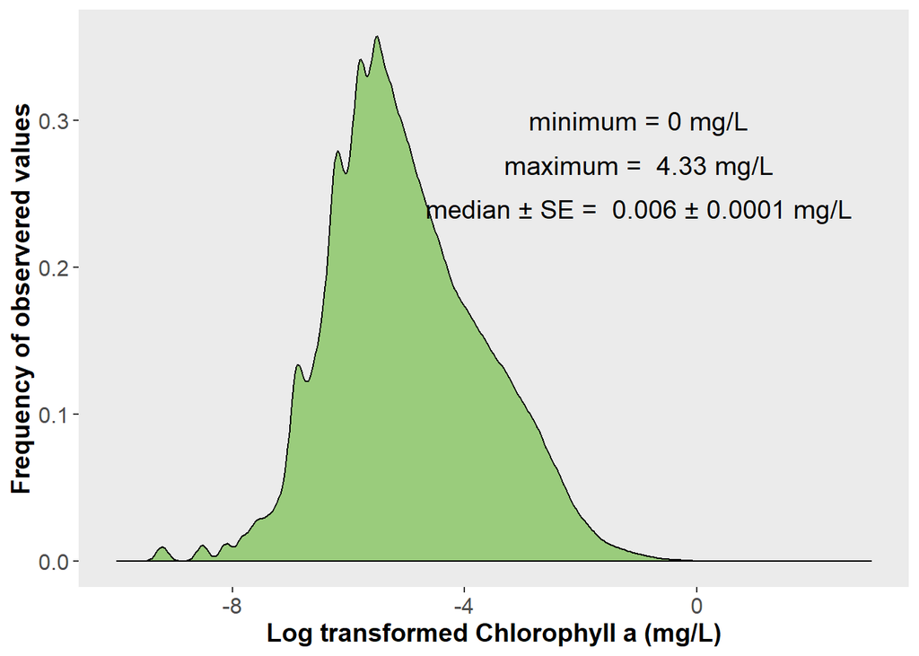

```r
## get standard error function
se <- function(x) sqrt(var(x)/length(x))


## Plot distribution of Chl values
ggplot(data, aes(x=log(ChlValues))) + geom_density(fill="#9ACC7C") + xlab("Log transformed Chlorophyll a (mg/L)") + ylab("Frequency of observered values") +
  annotate("text", x=-1, y=0.3, label=paste("minimum = 0 mg/L"), size=5) + ## min
  annotate("text", x=-1, y=0.27, label=paste("maximum = ",max(data$ChlValues), "mg/L"), size=5)  + ## max
  annotate("text", x=-1, y=0.24, label=paste("median ± SE = ",round(median(data$ChlValues),3), "±", formatC(round(se(data$ChlValues),4), digits=4,format="f") , "mg/L"), size=5) +theme(axis.text=element_text(size=12),
        axis.title=element_text(size=14,face="bold"))+ theme(panel.grid.major = element_blank(), panel.grid.minor = element_blank()) + xlim(-10,3)
```

```r
# + geom_vline(xintercept = log(2.5/1000), lty=2) + geom_vline(xintercept = log(0.001), lty=2)
```

### Check methods types

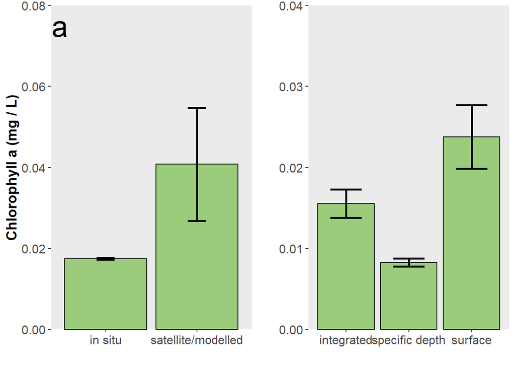

```r
method <- read.csv("data//methodsDataV2.csv", stringsAsFactors = F)


## merge methods file, chlorophyll, and survey information into one file
methodID <- merge(data, method, by="StudyID", all.x=T)


## method for calculating Chl
chlsurvey <- methodID %>% group_by(Survey.Type) %>% summarize(chl=mean(ChlValues), error=se(ChlValues)*1.96, n=length(ChlValues)) %>% filter(!Survey.Type %in% c("not described","undescribed","")) %>% filter(!is.na(Survey.Type))


plot1 <- ggplot(chlsurvey, aes(x=Survey.Type, y=chl))+ geom_bar(stat="identity", fill="#9ACC7C", color="black") + geom_errorbar(aes(x=Survey.Type,  ymin=chl-error, ymax=chl+error), lwd=1, width=0.2)  + xlab("") + ylab("Chlorophyll a (mg / L)")+theme(axis.text=element_text(size=12),
        axis.title=element_text(size=14,face="bold"))+ theme(panel.grid.major = element_blank(), panel.grid.minor = element_blank())+
   scale_y_continuous(expand = c(0, 0), limits = c(0,0.08)) + annotate(geom ="text", x=0.5, y=0.075, label="a", size=10)

## water survey location
chllocation <- methodID %>% group_by(Depth.qual) %>% summarize(chl=mean(ChlValues), error=se(ChlValues)*1.96, n=length(ChlValues)) %>% filter(!Depth.qual %in% c("not described","undescribed")) %>% filter(!is.na(Depth.qual))

plot2 <- ggplot(chllocation, aes(x=Depth.qual, y=chl))+ geom_bar(stat="identity", fill="#9ACC7C", color="black") + geom_errorbar(aes(x=Depth.qual,  ymin=chl-error, ymax=chl+error), lwd=1, width=0.5) +  xlab("") + ylab("")+theme(axis.text=element_text(size=12),
        axis.title=element_text(size=14,face="bold"))+ theme(panel.grid.major = element_blank(), panel.grid.minor = element_blank())+
  scale_y_continuous(expand = c(0, 0), limits = c(0,0.04))+ annotate(geom ="text", x=0.5, y=0.075, label="b", size=10)

library(gridExtra)

grid.arrange(plot1, plot2, ncol=2)
```

```r
## compare methods
method %>% group_by(Depth.qual) %>% summarize(n=length(Depth.quant))
```

```
## # A tibble: 4 x 2
##   Depth.qual         n
##   <chr>          <int>
## 1 integrated        68
## 2 specific depth    22
## 3 surface          118
## 4 undescribed       77
```

### Compare lakes frequency based on trophic status

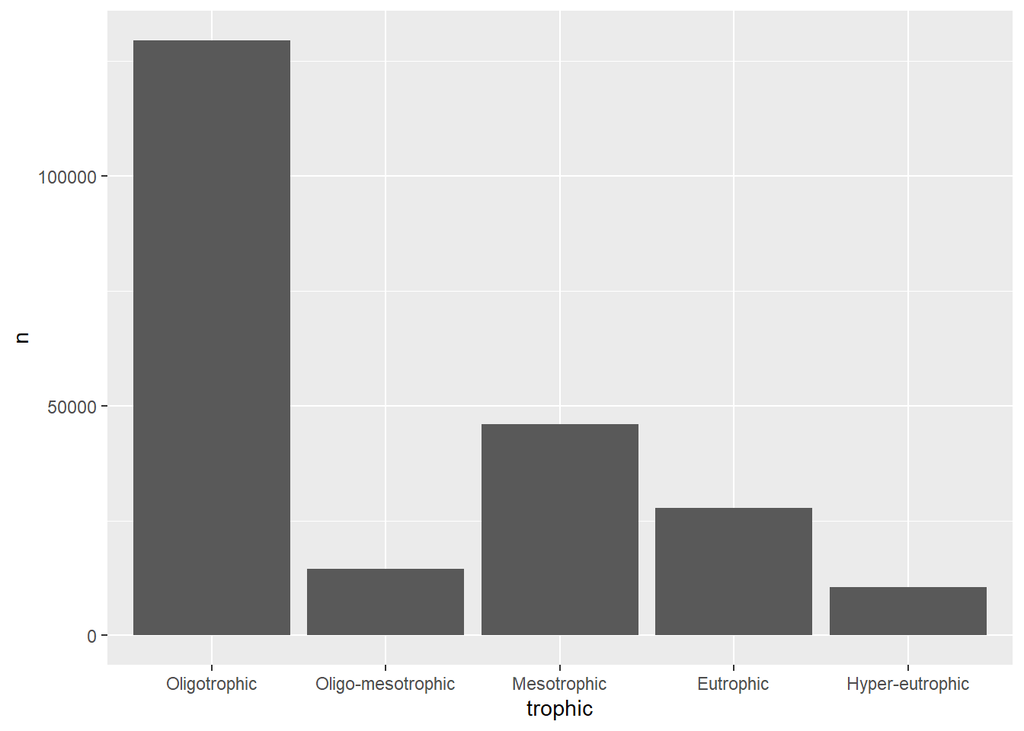

```r
chl <- data %>% mutate(Chl.ug = ChlValues*1000) %>%   mutate(trophic=cut(Chl.ug, breaks=c(-Inf, 7, 9, 26, 75, Inf), labels=c("Oligotrophic","Oligo-mesotrophic","Mesotrophic","Eutrophic","Hyper-eutrophic")))
## breaks taken from NWT Government Worksheet https://www.enr.gov.nt.ca/sites/enr/files/chlorophyll.pdf

chl.n <- chl %>% group_by(trophic) %>% summarize(n=length(Chl.ug))

## plot out lake frequency
ggplot(chl.n, aes(x=trophic, y=n)) + geom_bar(stat="identity")
```

### Summary statistics of dataset

```r
## Unique Lake IDs
data[,"UniqueLakeLocation"] <- paste0(data$Lat, data$Lon, sep=";")
data2 <-data
data2 <- data2[!duplicated(data2$UniqueLakeLocation),]

## number of unique locations
nrow(data2)
```

```
## [1] 15302
```

```r
## Number of Countries surveyed
library(maps)
data[,"CountryOfficial"] <- map.where(database="world", data$Lon, data$Lat)
## separate subcountry identifiers
country <- gsub("?:.*", "", data$CountryOfficial)
length(unique(country))
```

```
## [1] 72
```

```r
## water chem values
data %>% filter(!is.na(TN))  %>%  summarize(low=min(TN), high=max(TN), avg=mean(TN), n=length(TN), prop=n/nrow(data)) ## amount of TN values
```

```
##   low   high       avg     n      prop
## 1   0 20.574 0.9079891 39457 0.1729296
```

```r
data %>% filter(!is.na(TP))  %>%  summarize(low=min(TP), high=max(TP), avg=mean(TP), n=length(TP), prop=n/nrow(data))## amount of TP values
```

```
##   low high        avg      n      prop
## 1   0  3.6 0.04215493 111872 0.4903054
```

```r
data %>% filter(!is.na(DO))  %>%  summarize(low=min(DO), high=max(DO), avg=mean(DO), n=length(DO), prop=n/nrow(data))## amount of DO values
```

```
##      low high      avg   n        prop
## 1 1.3286 67.7 9.835084 761 0.003335262
```

```r
data %>% filter(!is.na(DOC))  %>%  summarize(low=min(DOC), high=max(DOC), avg=mean(DOC), n=length(DOC), prop=n/nrow(data))## amount of DOC values
```

```
##      low high         avg     n       prop
## 1 0.0001    1 0.007775983 10517 0.04609323
```

```r
data %>% filter(!is.na(pH))  %>%  summarize(low=min(pH), high=max(pH), avg=mean(pH), n=length(pH), prop=n/nrow(data)) ## amount of pH
```

```
##   low high      avg     n       prop
## 1 5.5 10.5 7.989574 12936 0.05669507
```

```r
data %>% filter(!is.na(ChlValues))  %>%  summarize(low=min(ChlValues), high=max(ChlValues), avg=mean(ChlValues), n=length(ChlValues), prop=n/nrow(data))
```

```
##   low high        avg      n prop
## 1   0 4.33 0.01749021 228168    1
```

```r
## lake char values
data %>% filter(!is.na(Depth.max))  %>%  summarize(low=min(Depth.max), high=max(Depth.max), avg=mean(Depth.max), n=length(Depth.max), prop = n/nrow(data)) ## max lake depth
```

```
##   low high      avg      n      prop
## 1   0  310 15.64502 188205 0.8248527
```

```r
data %>% filter(!is.na(Depth.mean))  %>%  summarize(low=min(Depth.mean), high=max(Depth.mean), avg=mean(Depth.mean), n=length(Depth.mean), prop = n/nrow(data))## mean lake depth
```

```
##   low high      avg     n      prop
## 1 0.2  154 6.999963 72786 0.3190018
```

```r
data %>% filter(!is.na(Secchi))  %>%  summarize(low=min(Secchi), high=max(Secchi), avg=mean(Secchi), n=length(Secchi), prop = n/nrow(data)) ## Secchi depth
```

```
##   low high      avg      n      prop
## 1   0 61.7 2.758682 195782 0.8580607
```

```r
data %>% filter(!is.na(SurfaceArea))  %>%  summarize(low=min(SurfaceArea), high=max(SurfaceArea), avg=mean(SurfaceArea), n=length(SurfaceArea), prop=n/nrow(data))  ## surface area
```

```
##   low     high      avg      n      prop
## 1   0 32056.74 25.11228 211975 0.9290304
```

```r
data %>% filter(!is.na(LakeVolume))  %>%  summarize(low=min(LakeVolume), high=max(LakeVolume), avg=mean(LakeVolume), n=length(LakeVolume), prop=n/nrow(data))  ## surface area
```

```
##      low       high       avg   n         prop
## 1 111700 9400000000 878218246 104 0.0004558045
```

### Create barplots of variables

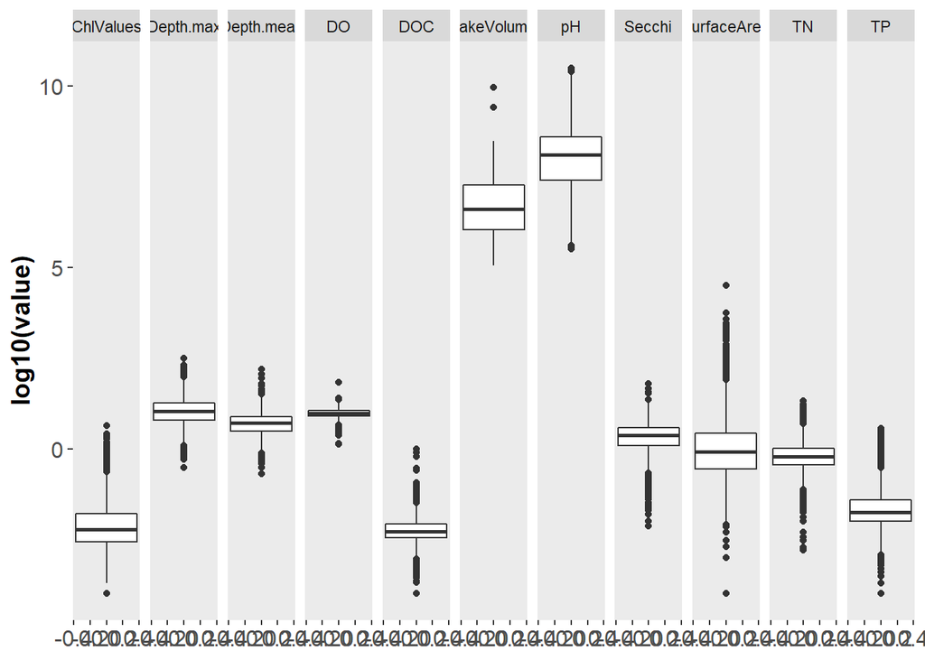

```r
chlaLong <- data %>% gather(variable, value, 9:19)

chlaLong[chlaLong$variable=="pH","value"] <- 10^chlaLong[chlaLong$variable=="pH","value"]

ggplot(chlaLong, aes(y=log10(value))) + geom_boxplot() + facet_grid(.~variable, scales="free") +theme(axis.text=element_text(size=12),
        axis.title=element_text(size=14,face="bold"))+ theme(panel.grid.major = element_blank(), panel.grid.minor = element_blank())
```

### Repository statistics

```r
## Select only repo datasets
data$StudyID <- as.character(data$StudyID)
repoData <- data[grep("repo*", data$StudyID),]

## Number of lakes
repoData %>% group_by(StudyID) %>% summarize(n=length(unique(UniqueLakeName)))
```

```
## # A tibble: 14 x 2
##    StudyID     n
##    <chr>   <int>
##  1 repo1      39
##  2 repo10      2
##  3 repo11     24
##  4 repo12     49
##  5 repo13    111
##  6 repo14   8218
##  7 repo2       1
##  8 repo3     215
##  9 repo4     332
## 10 repo5    2168
## 11 repo6      96
## 12 repo7    1059
## 13 repo8       7
## 14 repo9       1
```

```r
## Number of observations
repoData %>% group_by(StudyID) %>% summarize(n=length(uniqueID))
```

```
## # A tibble: 14 x 2
##    StudyID      n
##    <chr>    <int>
##  1 repo1     1231
##  2 repo10       8
##  3 repo11      24
##  4 repo12      52
##  5 repo13     112
##  6 repo14  209732
##  7 repo2      222
##  8 repo3      219
##  9 repo4      345
## 10 repo5     9568
## 11 repo6      103
## 12 repo7     1162
## 13 repo8      102
## 14 repo9      476
```

```r
## Timeframe
repoData %>%  group_by(StudyID) %>% mutate(Year = as.numeric(as.character(Year))) %>%  summarize(first = min(Year), last = max(Year))
```

```
## # A tibble: 14 x 3
##    StudyID first  last
##    <chr>   <dbl> <dbl>
##  1 repo1    1969  2017
##  2 repo10   2008  2011
##  3 repo11   2000  2000
##  4 repo12   1998  2000
##  5 repo13   1999  2004
##  6 repo14   1933  2013
##  7 repo2    1975  2018
##  8 repo3    1975  1985
##  9 repo4    2015  2015
## 10 repo5    1967  2019
## 11 repo6    1974  2010
## 12 repo7    2007  2007
## 13 repo8    1993  2018
## 14 repo9    1977  2016
```

### Methods summary variables

```r
method <- read.csv("data//methodsDataV2.csv", stringsAsFactors = F)

method %>% group_by(Survey.Type) %>% summarize(n=length(Survey.Type))
```

```
## # A tibble: 3 x 2
##   Survey.Type            n
##   <chr>              <int>
## 1 in situ              238
## 2 satellite/modelled    10
## 3 undescribed           37
```

```r
method %>% group_by(DepthDetails) %>% summarize(n=length(DepthDetails))
```

```
## # A tibble: 8 x 2
##   DepthDetails                  n
##   <chr>                     <int>
## 1 "epilimnion "                 4
## 2 "hypolimnion"                 2
## 3 "integrated water sample"    34
## 4 "metadata"                    4
## 5 "range"                      99
## 6 "sampling station"            1
## 7 "surface water sample "      43
## 8 "undescribed"                98
```

```r
max(method$DepthDeep, na.rm=T) ## Lake Baikal
```

```
## [1] 250
```

```r
method %>% group_by(DetectionLimits) %>% summarize(n=length(DetectionLimits))
```

```
## # A tibble: 8 x 2
##   DetectionLimits     n
##             <dbl> <int>
## 1         0.00001    40
## 2         0.00005     1
## 3         0.0001    161
## 4         0.0005      1
## 5         0.001      35
## 6         0.01       18
## 7         0.1        18
## 8        NA          11
```